# Structural Topic Modeling

# Analysis of US Blog Posts

Winn Pham

2023-10-19

## 1. Import the libraries and load the dataset

```r
library(wordcloud)
library(stm)
library(igraph)
df <- read.csv("poliblogs2008.csv")
head(df)
```

```
##   X
## 1 1
## 2 2
## 3 3
## 4 4
## 5 5
## 6 6
##                                                                                                                                                                                                                                                                                                          …
## 1                                                                                                                                                                                                                                                                                                        …
## 2                                                                                                                                                                                                                                                                                                        …
## 3                                                                                                                                                                                                                                                                                                        …
## 4                                                                                                                                                                                                                                                                                                        …
## 5                                                                                                                                                                                                                                                                                                        …
## 6 Mike Huckabee is pretty slick. He's the one Republican who's been boosted by the big media. Those media headlines got him off to a fast start. But a couple of days ago he got the press laughing at his shenanigans with his "I'm NOT negative!" press conference. "Mike Huckabee said Monday he would…
##            docname       rating day blog
## 1 at0800300_1.text Conservative   3   at
## 2 at0800300_2.text Conservative   3   at
## 3 at0800300_3.text Conservative   3   at
## 4 at0800300_4.text Conservative   3   at
## 5 at0800300_5.text Conservative   3   at
## 6 at0800300_6.text Conservative   3   at
```

```r
summary(df)
```

```
##        X          documents           docname             rating
##  Min.   :    1   Length:13246       Length:13246       Length:13246
##  1st Qu.: 3312   Class :character   Class :character   Class :character
##  Median : 6624   Mode  :character   Mode  :character   Mode  :character
##  Mean   : 6624
##  3rd Qu.: 9935
##  Max.   :13246
##       day            blog
##  Min.   :  1.0   Length:13246
##  1st Qu.:110.0   Class :character
##  Median :201.0   Mode  :character
##  Mean   :193.5
##  3rd Qu.:277.0
##  Max.   :366.0
```

```r
#Sample randomly 1000 rows from the loaded dataset and remove unnecessary columns
set.seed(100)
df <- df[sample(nrow(df),1000),-c(1,3,6)]
summary(df)
```

```
##   documents            rating               day
##  Length:1000        Length:1000        Min.   :  1.0
##  Class :character   Class :character   1st Qu.:119.8
##  Mode  :character   Mode  :character   Median :204.0
##                                        Mean   :195.4
##                                        3rd Qu.:278.2
##                                        Max.   :366.0
```

```r
#Check for data accuracy
##factor the categorical variables
df$rating <- factor(df$rating)
table(df$rating)
```

```
##
## Conservative      Liberal
##          595          405
```

```r
#Check for missing data
apply(df, 2, function(x) { sum(is.na(x)) })# There's no missing data
```

```
## documents    rating       day
##         0         0         0
```

## 2. Preprocessing data

First, use Regex to remove noise from the documents.

```r
df$documents = gsub('&amp;', ' and ', df$documents)
df$documents = gsub('(@[A-za-z0-9]*)\\s', '@ ', df$documents)
df$documents = gsub('(@[A-za-z0-9]*):\\s', '@ ', df$documents)
df$documents = gsub('(#[A-za-z0-9]*)\\s', '# ', df$documents)
df$documents = gsub('https:\\/\\/.*?\\s', 'url ', df$documents)
df$documents = gsub('<.*?>', ' emoji ', df$documents)
```

Then, several preprocessing steps are then performed by using textProcessor function including: - convert to lower case - remove stop words - remove numbers - remove punctuation - stemming - remove infrequent words - remove words shorter than the minimum word length (default minimum length is 3) *These are set as default*

```r
#metadata includes rating and day columns
meta_df = df[,c('rating', 'day')]
processed_df <- textProcessor(df$documents, metadata = meta_df,
                           lowercase = TRUE, #default
                           removestopwords = TRUE,#default
                           removenumbers = TRUE,#default
                           stem = TRUE,#default
                           wordLengths = c(3,Inf),#default
                           sparselevel = 1,#default
                           language = 'en',#default
                           verbose = TRUE,#default
                           onlycharacter = TRUE, # NOT default
                           striphtml = FALSE, #default
                           customstopwords = NULL,#default
                           v1 = FALSE) #default
```

```
## Building corpus...
## Converting to Lower Case...
## Removing punctuation...
## Removing stopwords...
## Removing numbers...
## Stemming...
## Creating Output...
```

prepDocuments function performs several corpus manipulations including removing words and renumbering word indices (correct for zero-indexing and unused words in the vocab vector); provide additional methods to prune infrequent words. Or in other words, this function processes the loaded data to ensure the format is correct.

```r
prep_df <- prepDocuments(processed_df$documents, processed_df$vocab, processed_df$meta)
```

```
## Removing 6521 of 14897 terms (6521 of 172823 tokens) due to frequency
## Your corpus now has 1000 documents, 8376 terms and 166302 tokens.
```

```r
docs <- prep_df$documents
vocab <- prep_df$vocab
meta <- prep_df$meta
```

## 3. Run the Topic model with topical prevalence covariates

Fit a 10 topic model with both rating and day as Topical prevalence covariates The continuous covariate day can be transformed to a more flexible functional forms. For instance,the s() function can be used to select a more flexible b-spline basis. I set the maximum number of iterations for the estimation algorithm as 75.And in order to produce the best results consistently, the spectral initialization is recommended

```r
stm_model <- stm(documents = prep_df$documents, vocab = prep_df$vocab, K = 10, prevalence = ~rating+s(day), max.em.its = 75, data = prep_df$meta, init.type = "Spectral")
```

[output not shown]

[output cut: 392 more lines]

[output not shown]

```r
# Select <- selectModel(prep_df$documents,prep_df$vocab, K =10, prevalence = ~rating +day, max.em.its = 75, data = prep_df$meta, runs=20, seed = 8458159)
# plotModels(Select, pch = c(1,2,3,4))
```

## 4. Dipslaying words associated with topics

```r
#Print all 10 topics
labelTopics(stm_model, c(1:10))
```

```
## Topic 1 Top Words:
##       Highest Prob: democrat, vote, republican, clinton, will, elect, state
##       FREX: franken, coleman, deleg, poll, gop, primari, clinton
##       Lift: altmir, avant, balart, beam, bearer, begich, berni
##       Score: hillari, poll, primari, rendel, franken, gop, coleman
## Topic 2 Top Words:
##       Highest Prob: obama, mccain, campaign, barack, polit, will, time
##       FREX: ayer, wright, obama, edmund, barack, khalidi, pfleger
##       Lift: bernadin, dilettant, disinvit, doctrinair, fallback, fluster, geraldin
##       Score: obama, ayer, wright, mccain, edmund, biden, brokaw
## Topic 3 Top Words:
##       Highest Prob: one, year, can, will, time, global, warm
##       FREX: mugab, warm, ice, student, global, islam, scienc
##       Lift: fetus, herd, hip, hoo, inward, migrat, mugab
##       Score: saul, mugab, bishop, ice, sanchez, parasit, zimbabw
## Topic 4 Top Words:
##       Highest Prob: tax, mccain, will, plan, govern, oil, spend
##       FREX: tax, fanni, plumber, spend, billion, market, loan
##       Lift: amt, ari, columbian, cornerston, dow, eagleburg, exxonmobil
##       Score: tax, mccain, dividend, plumber, mortgag, fanni, recess
## Topic 5 Top Words:
##       Highest Prob: one, like, get, make, just, russia, can
##       FREX: georgian, russia, russian, film, georgia, putin, hunter
##       Lift: aden, aol, balkan, berlusconi, blacklist, boatload, cafe
##       Score: russia, film, russian, daley, georgian, georgia, putin
## Topic 6 Top Words:
##       Highest Prob: mccain, palin, say, updat, said, john, romney
##       FREX: romney, mitt, palin, huck, sarah, huckabe, fox
##       Lift: allowfullscreen, allowscriptaccess, antic, antonio, appendchild, babbl, bgcolor
##       Score: palin, mccain, romney, huckabe, huck, hage, scriptalreadyrequest
## Topic 7 Top Words:
##       Highest Prob: will, peopl, american, countri, america, one, liber
##       FREX: liber, patriot, honor, love, halperin, veteran, america
##       Lift: annihil, antiwar, apathi, assimil, atroci, birmingham, blink
##       Score: halperin, berkeley, maf, corsi, puriti, auschwitz, enlist
## Topic 8 Top Words:
##       Highest Prob: said, court, law, report, senat, one, state
##       FREX: court, investig, justic, law, letter, constitut, legal
##       Lift: abdel, acquit, affidavit, amherst, aurora, barg, boumedien
##       Score: court, brownback, detaine, arrest, affidavit, detent, telecommun
## Topic 9 Top Words:
##       Highest Prob: will, iraq, state, forc, govern, year, iraqi
##       FREX: sadr, mahdi, maliki, iraqi, agreement, withdraw, militia
##       Lift: attende, buckl, bureaus, cattl, compact, corker, countrysid
##       Score: iraqi, sadr, maliki, mahdi, basra, sofa, sunni
## Topic 10 Top Words:
##       Highest Prob: bush, iraq, presid, war, said, iran, polici
##       FREX: israel, iran, fallon, cheney, afghanistan, qaeda, lebanon
##       Lift: brandenburg, envoy, irgc, prematur, samantha, sleiman, esquir
##       Score: fallon, iran, israel, iraqi, isra, syria, iranian
```

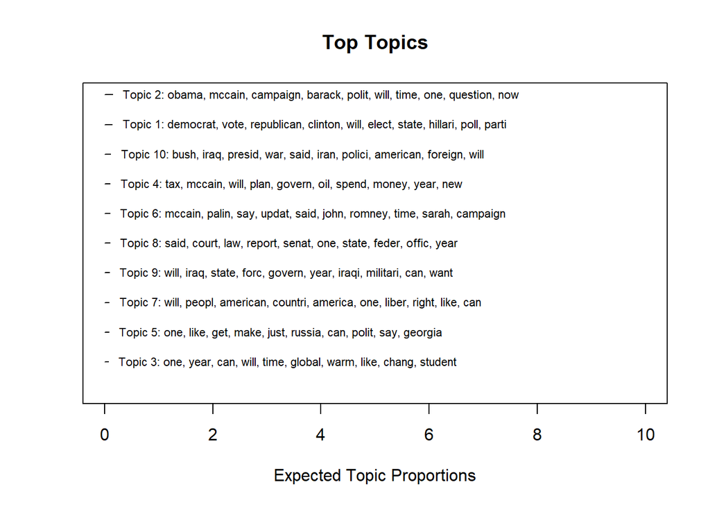

```r
plot.STM(stm_model, type="summary", xlim=c(0,10), n = 10, text.cex = 0.7)
```

- Print the 3 most representative documents for each topic then

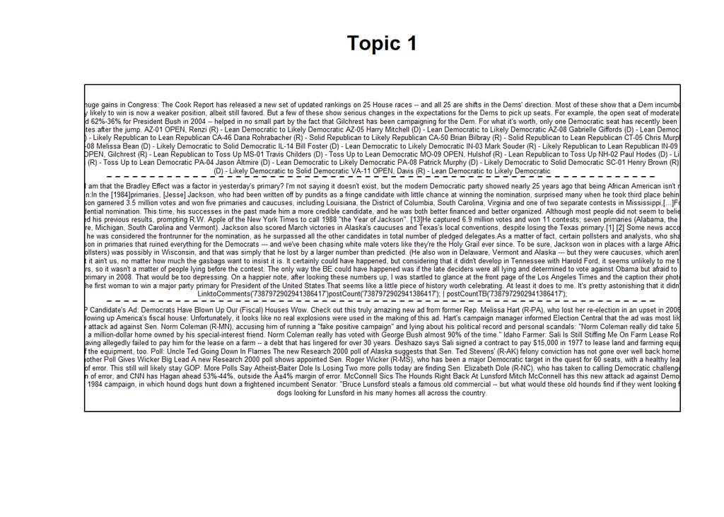

```r
#Subset to make getting representative documents faster
rownames(df) <- 1:nrow(df)
rows = list(names(docs))
df_sub = df[rownames(df) %in% rows[[1]], ]

thoughts1 <- findThoughts(stm_model, texts = df_sub$documents, n=3, topics=1)$docs[[1]]
plotQuote(thoughts1, width=300, main="Topic 1", text.cex = 0.4)
```

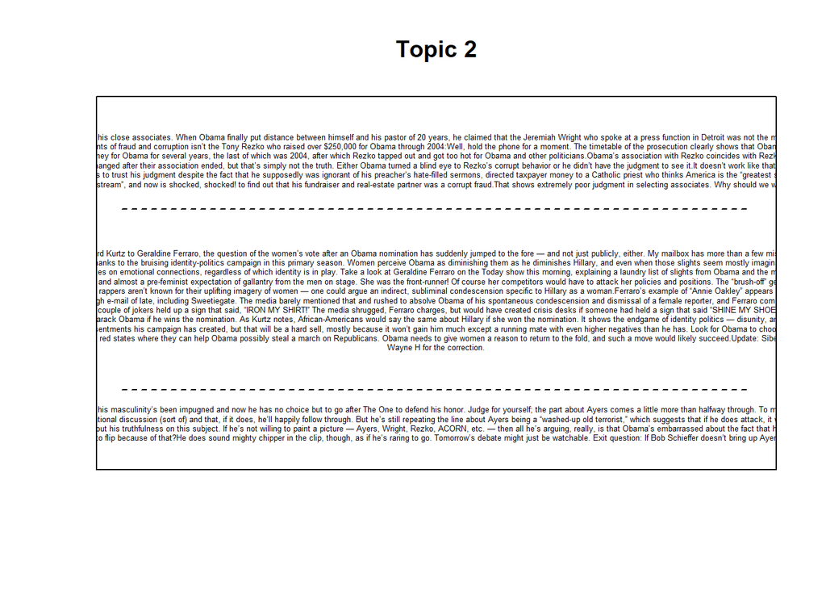

```r
thoughts2 <- findThoughts(stm_model, texts = df_sub$documents, n=3, topics=2)$docs[[1]]
plotQuote(thoughts2, width=300, main="Topic 2", text.cex = 0.4)
```

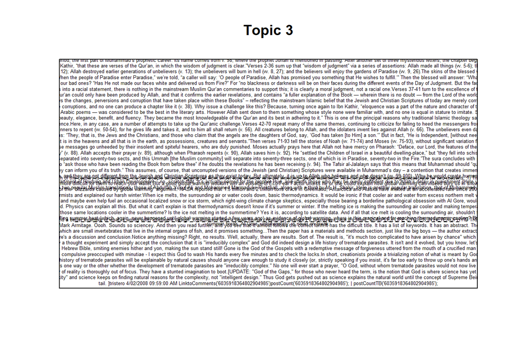

```r
thoughts3 <- findThoughts(stm_model, texts = df_sub$documents, n=3, topics=3)$docs[[1]]
plotQuote(thoughts3, width=300, main="Topic 3", text.cex = 0.4)
```

[figure not shown]

```r
thoughts4 <- findThoughts(stm_model, texts = df_sub$documents, n=3, topics=4)$docs[[1]]
plotQuote(thoughts4, width=300, main="Topic 4", text.cex = 0.4)
```

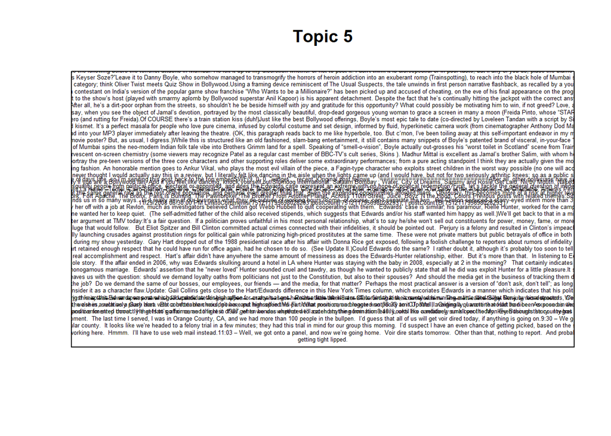

```r
thoughts5 <- findThoughts(stm_model, texts = df_sub$documents, n=3, topics=5)$docs[[1]]
plotQuote(thoughts5, width=300, main="Topic 5", text.cex = 0.4)
```

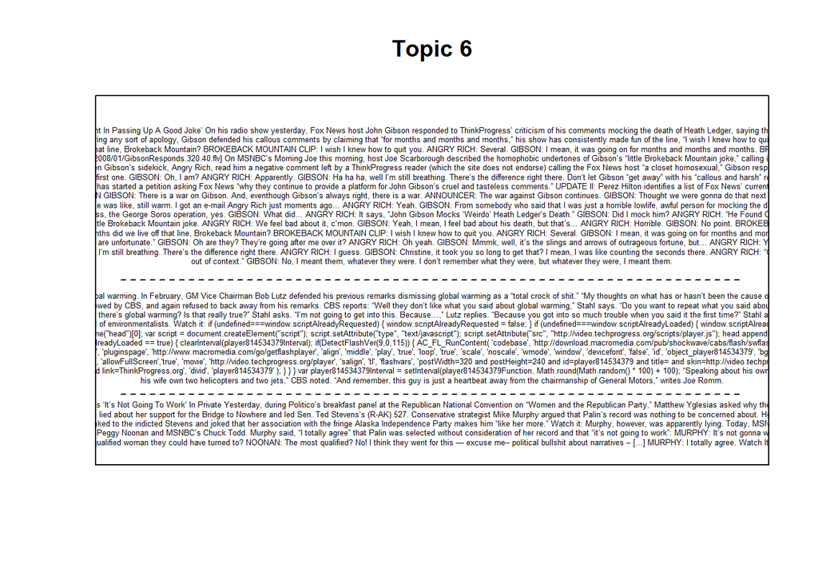

```r
thoughts6 <- findThoughts(stm_model, texts = df_sub$documents, n=3, topics=6)$docs[[1]]
plotQuote(thoughts6, width=300, main="Topic 6", text.cex = 0.4)
```

[figure not shown]

```r
thoughts7 <- findThoughts(stm_model, texts = df_sub$documents, n=3, topics=7)$docs[[1]]
plotQuote(thoughts7, width=300, main="Topic 7", text.cex = 0.4)
```

[figure not shown]

```r
thoughts8 <- findThoughts(stm_model, texts = df_sub$documents, n=3, topics=8)$docs[[1]]
plotQuote(thoughts8, width=300, main="Topic 8", text.cex = 0.4)
```

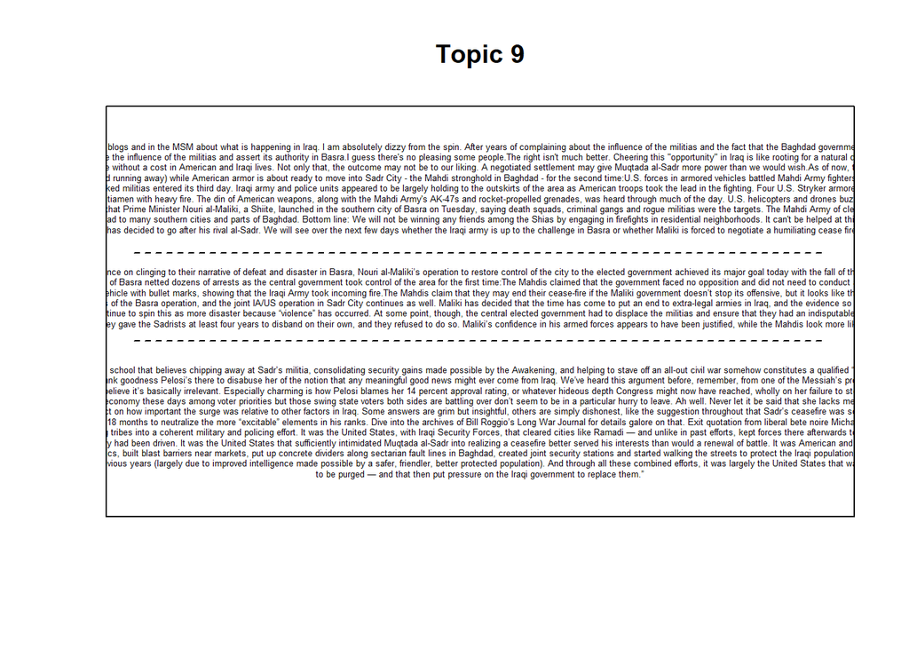

```r
thoughts9 <- findThoughts(stm_model, texts = df_sub$documents, n=3, topics=9)$docs[[1]]
plotQuote(thoughts9, width=300, main="Topic 9", text.cex = 0.4)
```

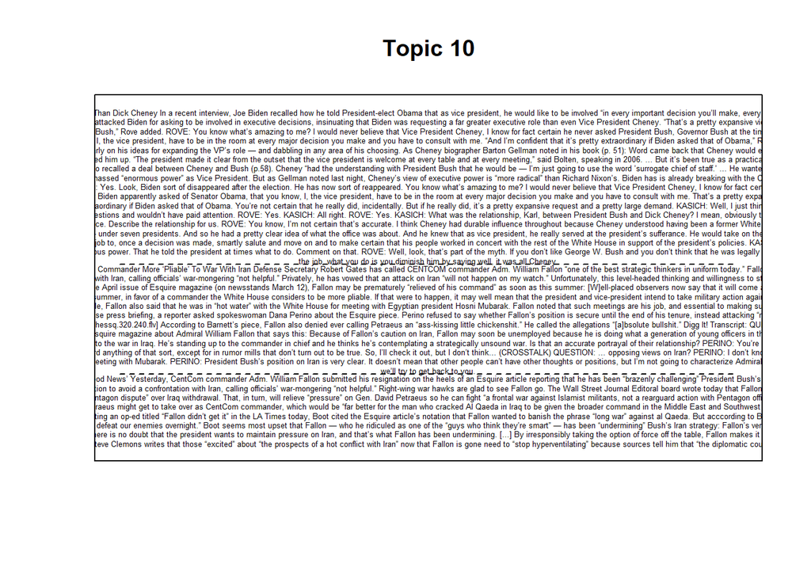

```r
thoughts10 <- findThoughts(stm_model, texts = df_sub$documents, n=3, topics=10)$docs[[1]]
plotQuote(thoughts10, width=300, main="Topic 10", text.cex = 0.4)
```

- Review word distribution per specific topic.

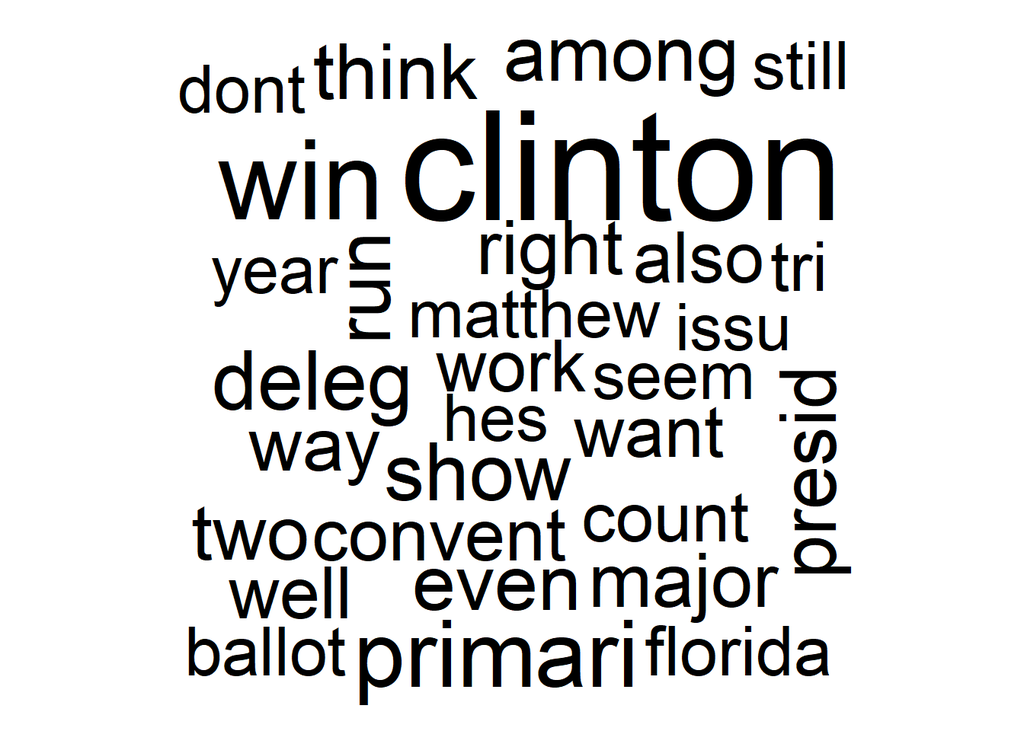

```r
cloud(stm_model,topic=1, scale = c(10,2))
```

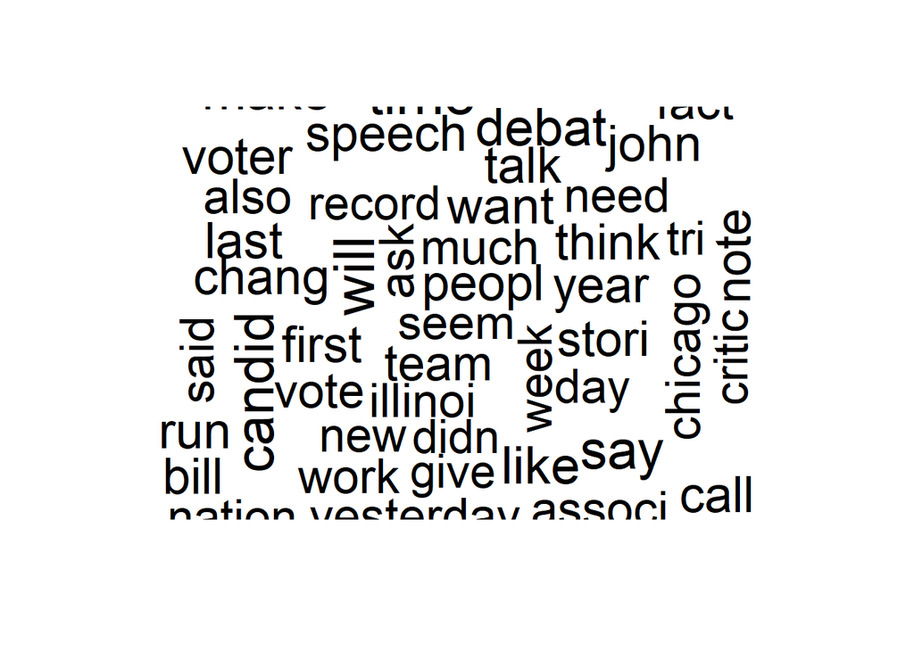

```r
cloud(stm_model,topic=2, scale = c(10,2))
```

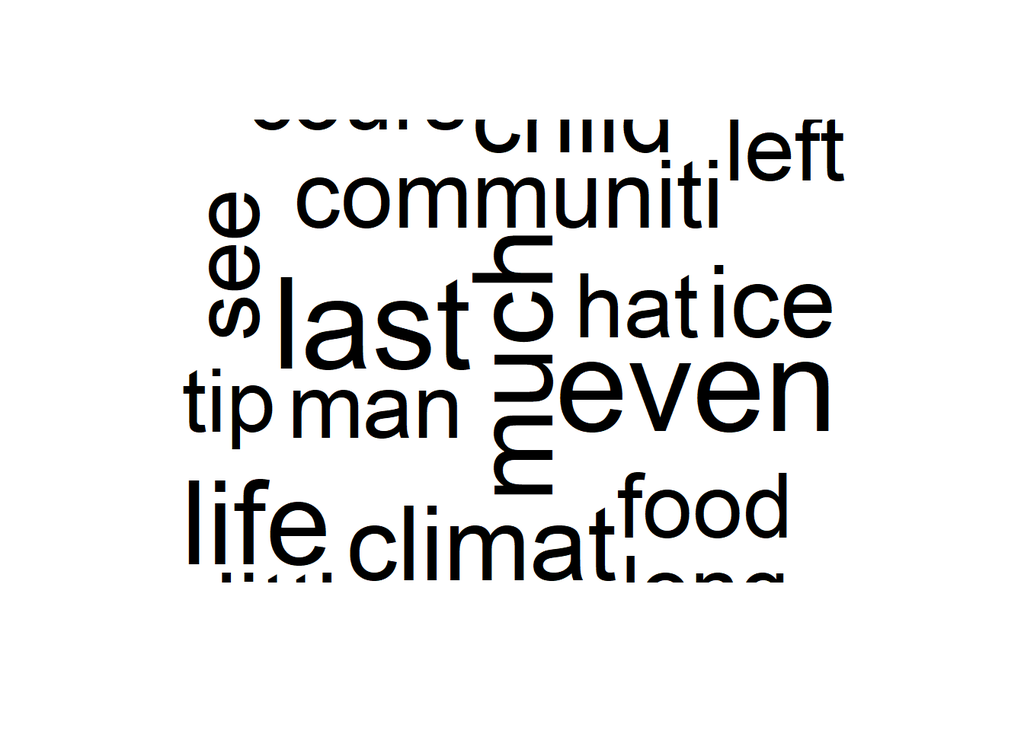

```r
cloud(stm_model,topic=3, scale = c(10,2))
```

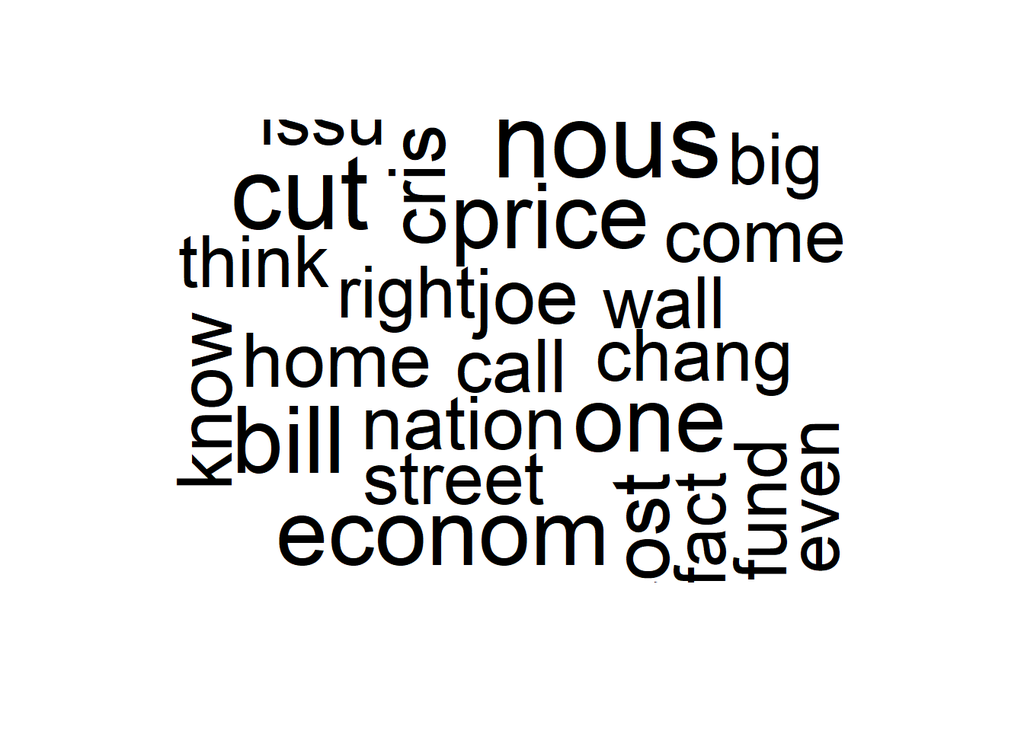

```r
cloud(stm_model,topic=4, scale = c(10,2))
```

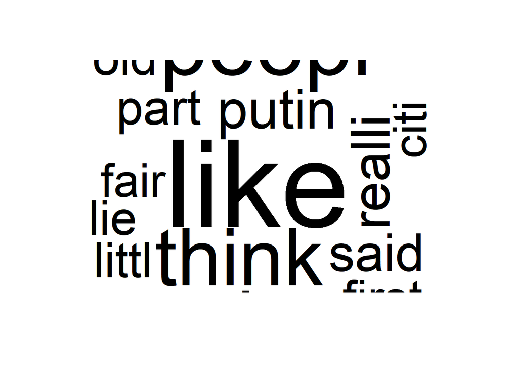

```r
cloud(stm_model,topic=5, scale = c(10,2))
```

[figure not shown]

```r
cloud(stm_model,topic=6, scale = c(10,2))
```

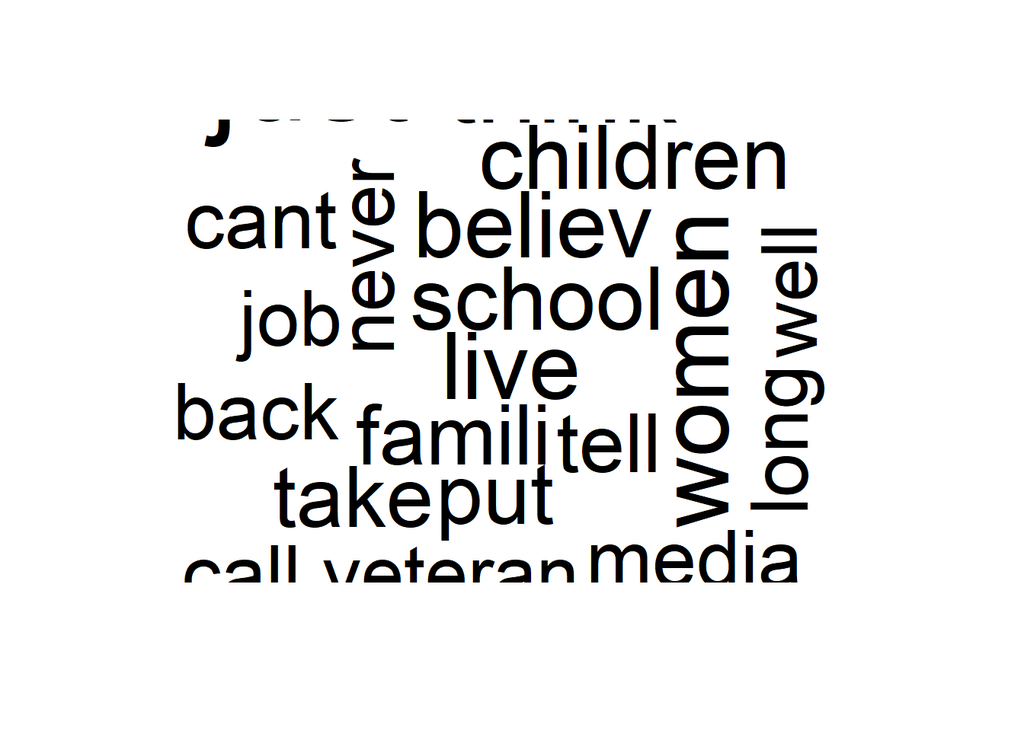

```r
cloud(stm_model,topic=7, scale = c(10,2))
```

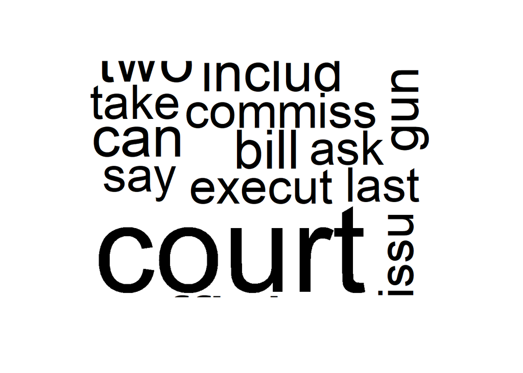

```r
cloud(stm_model,topic=8, scale = c(10,2))
```

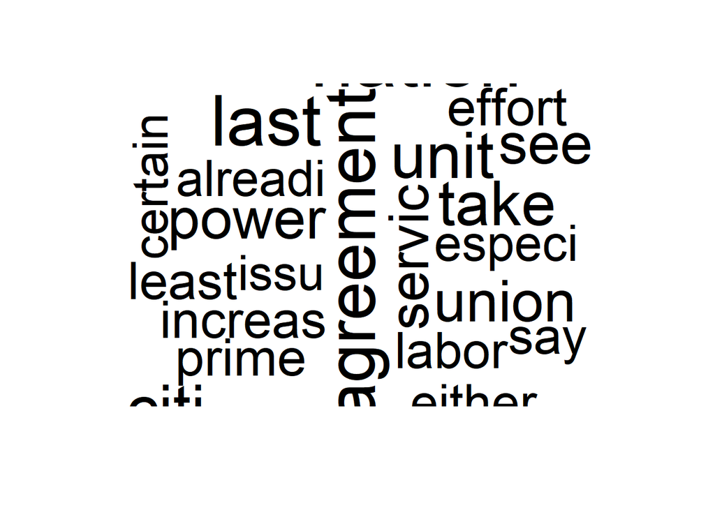

```r
cloud(stm_model,topic=9, scale = c(10,2))
```

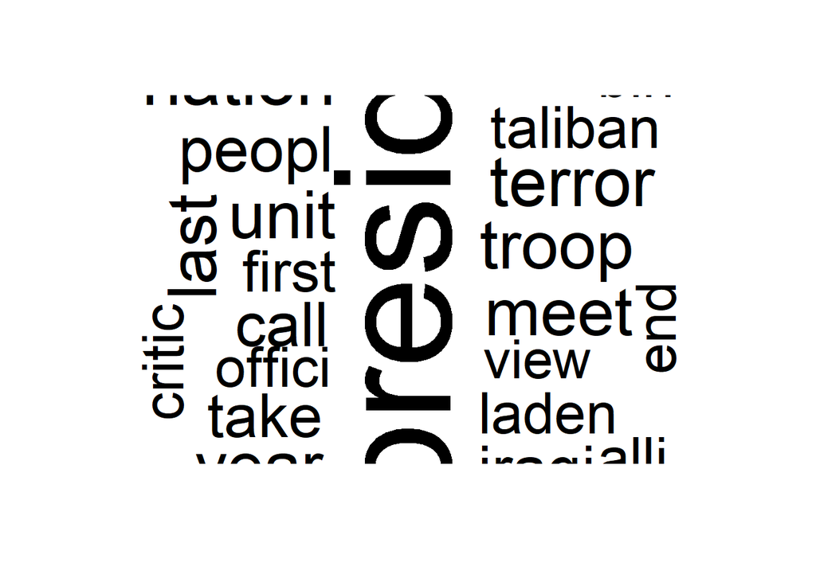

```r
cloud(stm_model,topic=10, scale = c(10,2))
```

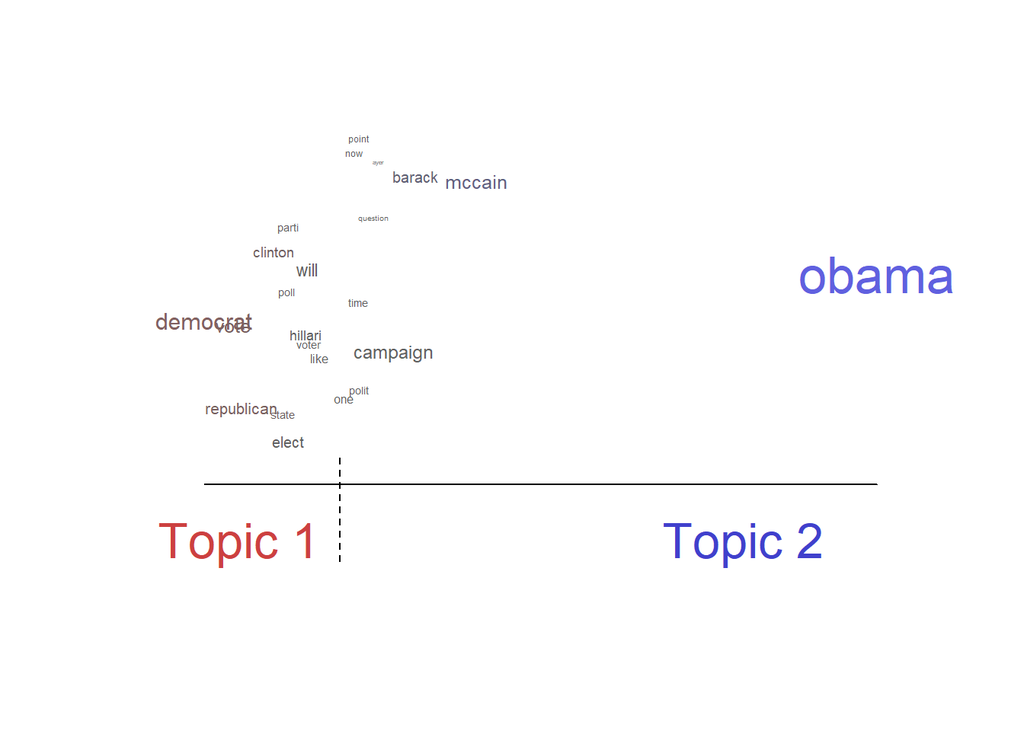

```r
#compare between 2 topics to see how the terms differ
plot(stm_model, type = "perspectives", topics = c(1,2))
```

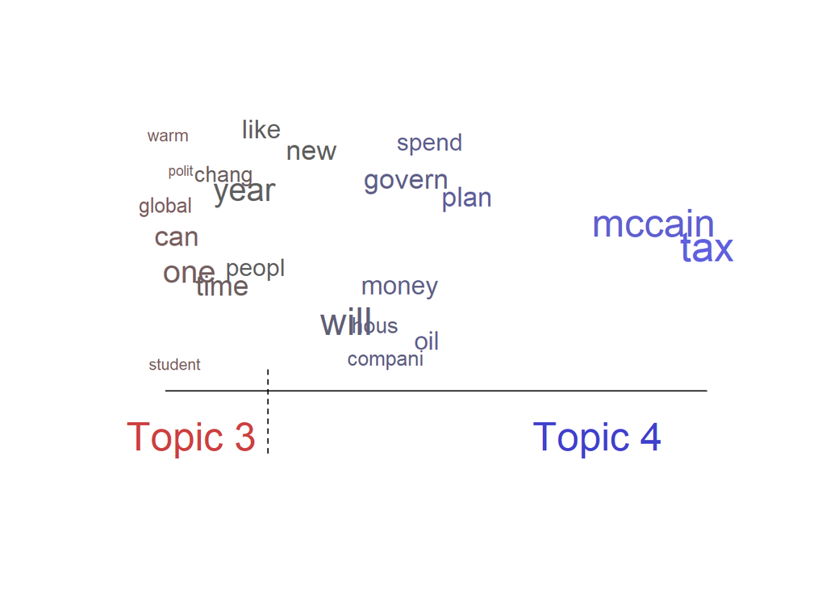

```r
plot(stm_model, type = "perspectives", topics = c(3,4))
```

- Evaluate the topic correlation

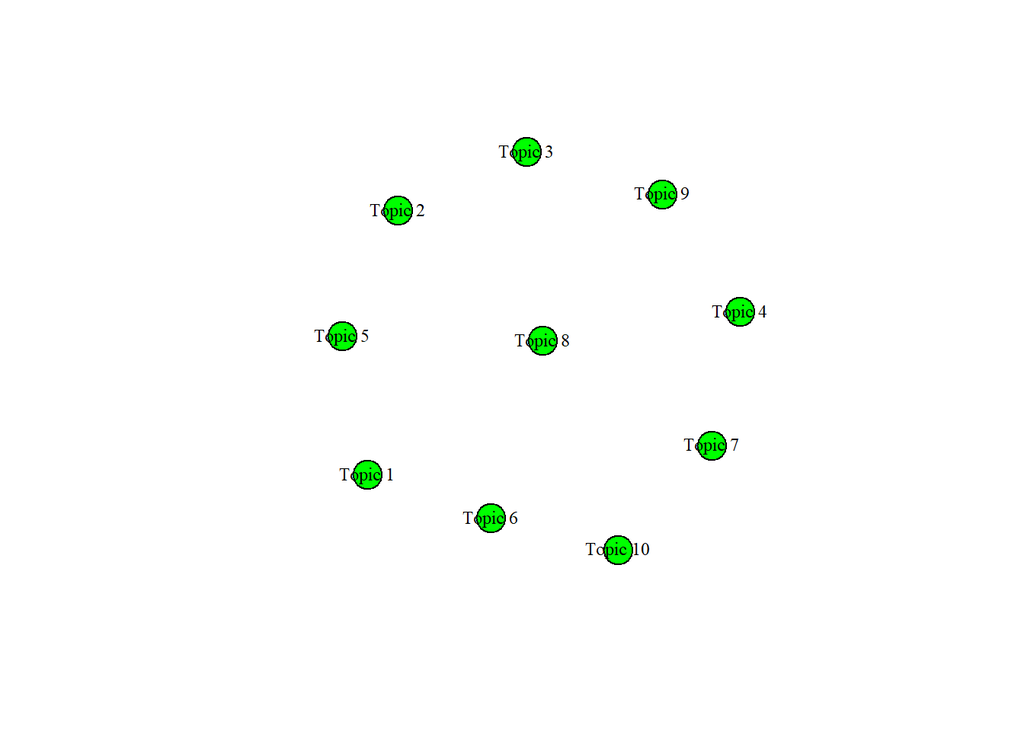

```r
topic_correlation <- topicCorr(stm_model)
plot(topic_correlation)
```